# Golovin_8

## HOMEWORK 8

## Подготовка файла топологии этана.

```python
# загрузим модули
import rdkit
from rdkit import Chem
from rdkit.Chem import AllChem, Draw
from rdkit.Chem import Descriptors
from rdkit import RDConfig
from IPython.display import Image,display
import numpy as np

from IPython.display import HTML
from base64 import b64encode
```

```python
# создадим этан
mol=Chem.MolFromSmiles('CC')
AllChem.Compute2DCoords(mol)
m3d=Chem.AddHs(mol)
Chem.AllChem.EmbedMolecule(m3d)
AllChem.MMFFOptimizeMolecule(m3d,maxIters=500,nonBondedThresh=200 )
```

```
0
```

Находим информацию об атомах С и Н в файле /usr/share/gromacs/top/oplsaa.ff/forcefield.itp

```python
atomtypes = """
name   at.num       mass     charge ptype  sigma      epsilon
H          1        1.008    0.0000  A   1.06908e-01  1.00000e-00
C          6        12.01    0.0000  A   3.39967e-01  3.59824e-01"""
```

```python
## связи
bonds = m3d.GetBonds()
for i,b in enumerate(bonds):
    print b.GetBeginAtomIdx()+1 , b.GetEndAtomIdx()+1, 1
```

```
1 2 1
1 3 1
1 4 1
1 5 1
2 6 1
2 7 1
2 8 1
```

```python
## углы
need = range(3,9)
for b1 in m3d.GetBonds():
    for b2 in m3d.GetBonds():
        if b1.GetBeginAtomIdx() == b2.GetBeginAtomIdx() and b1.GetIdx() != b2.GetIdx():
            print b1.GetEndAtomIdx()+1 , b1.GetBeginAtomIdx()+1, b2.GetEndAtomIdx()+1, 1
```

```
2 1 3 1
2 1 4 1
2 1 5 1
3 1 2 1
3 1 4 1
3 1 5 1
4 1 2 1
4 1 3 1
4 1 5 1
5 1 2 1
5 1 3 1
5 1 4 1
6 2 7 1
6 2 8 1
7 2 6 1
7 2 8 1
8 2 6 1
8 2 7 1
```

Отсюда надо убрать (руками это быстрее) повторябщиеся углы.

```python
## торсионные углы
for b1 in m3d.GetBonds():
    for b2 in m3d.GetBonds():
        for b3 in m3d.GetBonds():
            if b1.GetBeginAtomIdx() == b2.GetBeginAtomIdx() and b2.GetEndAtomIdx() == b3.GetBeginAtomIdx()and b1.GetIdx() != b2.GetIdx():
                print b1.GetEndAtomIdx()+1 , b1.GetBeginAtomIdx()+1, b2.GetEndAtomIdx()+1, b3.GetEndAtomIdx()+1, 1
```

```
3 1 2 6 1
3 1 2 7 1
3 1 2 8 1
4 1 2 6 1
4 1 2 7 1
4 1 2 8 1
5 1 2 6 1
5 1 2 7 1
5 1 2 8 1
```

Теперь у нас есть все необходимые данные для топологии этана. Можно их добавить в итоговый файл.

## Разные методы контроля температуры

Скачаем файлы с разными параметрами контроля температуры: be.mdp, an.mdp, nh.mdp, sd.mdp, vr.mdp. Построим входные файлы для молекулярно-динамического движка mdrun с помощью grompp. Получится 5 tpr файлов. Теперь для каждого из них запустим mdrun, а затем перевели в pdb.

% bash

export i="be", "an", "nh", "sd", "vr"

grompp -f %s.mdp -c et.gro -p et.top -o et_%s.tpr

mdrun -deffnm et_%s -v -nt 1

Заметно, что этан обработанный разными методами ведет себя по-разному. Где-то его сильно крутит, а где-то просто меняется длина связи СС. Лучше всего это все понятно на видео :)

#### метод Андерсена

```python
video = open('an.mp4', 'rb').read()
video_encoded = b64encode(video)
video_tag = '<video controls alt="PyMol Movie" src="data:video/mp4;base64,{0}" type="video/mp4">'.format(video_encoded)
HTML(data=video_tag)
```

[video not shown]

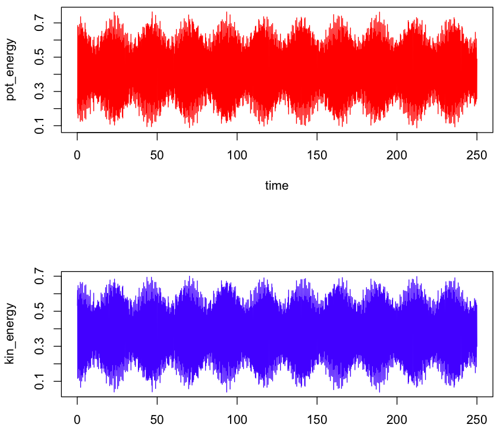

```python
Image(filename = "an.png", width=500, height=500)
```

#### метод Берендсена

```python
video = open('be.mp4', 'rb').read()
video_encoded = b64encode(video)
video_tag = '<video controls alt="PyMol Movie" src="data:video/mp4;base64,{0}" type="video/mp4">'.format(video_encoded)
HTML(data=video_tag)
```

[video not shown]

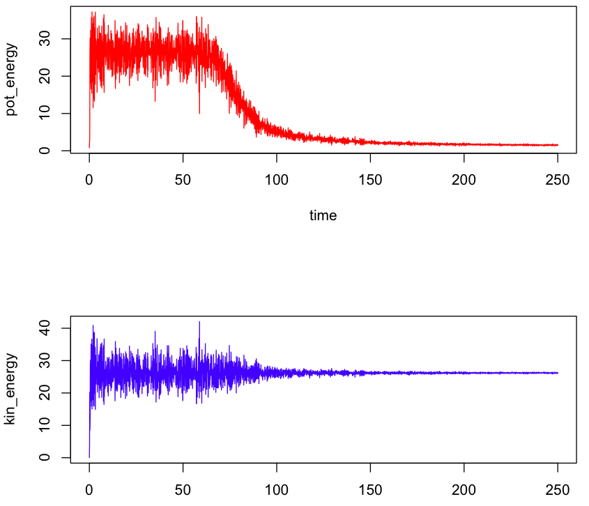

```python
Image(filename = "be.png", width=500, height=500)
```

#### метод Нуза-Хувера

```python
video = open('nh.mp4', 'rb').read()
video_encoded = b64encode(video)
video_tag = '<video controls alt="PyMol Movie" src="data:video/mp4;base64,{0}" type="video/mp4">'.format(video_encoded)
HTML(data=video_tag)
```

[video not shown]

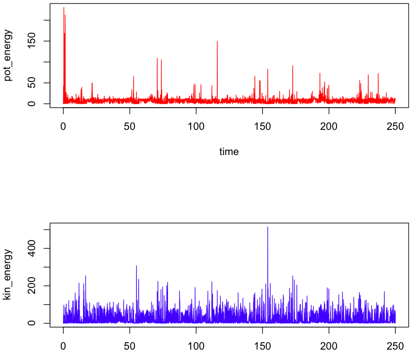

```python
Image(filename = "nh.png", width=500, height=500)
```

#### метод стохастической молекулярной динамики

```python
video = open('sd.mp4', 'rb').read()
video_encoded = b64encode(video)
video_tag = '<video controls alt="PyMol Movie" src="data:video/mp4;base64,{0}" type="video/mp4">'.format(video_encoded)
HTML(data=video_tag)
```

[video not shown]

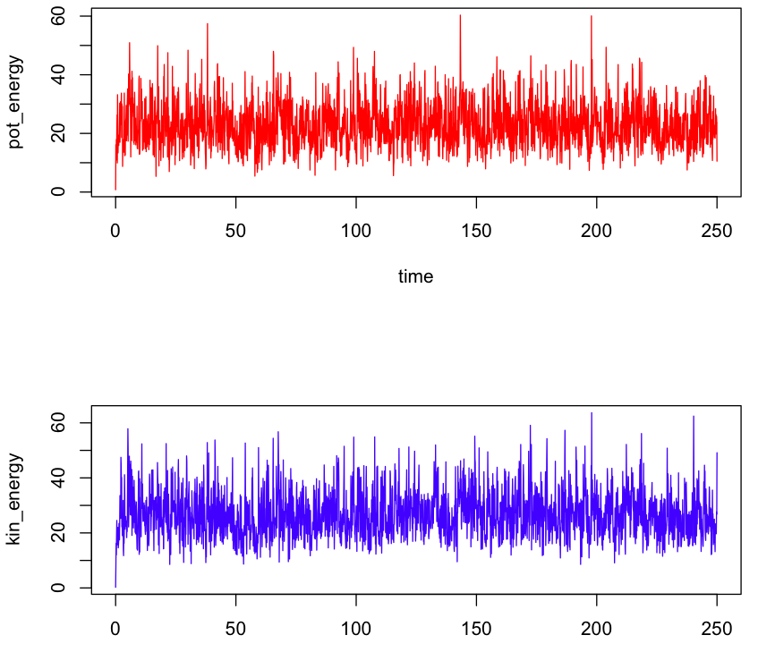

```python
Image(filename = "sd.png", width=500, height=500)
```

#### метод "Velocity rescale"

```python
video = open('vr.mp4', 'rb').read()
video_encoded = b64encode(video)
video_tag = '<video controls alt="PyMol Movie" src="data:video/mp4;base64,{0}" type="video/mp4">'.format(video_encoded)
HTML(data=video_tag)
```

[video not shown]

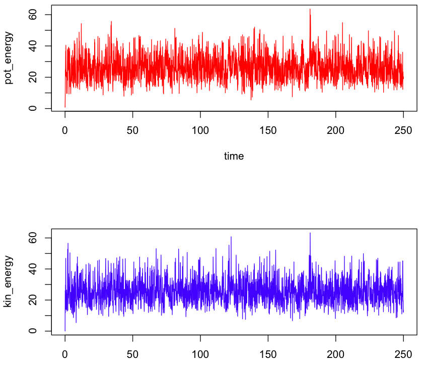

```python
Image(filename = "vr.png", width=500, height=500)
```

Теперь построим длину связи С-С. Цвета графиков соотвествуют цветам молекул на видео :)

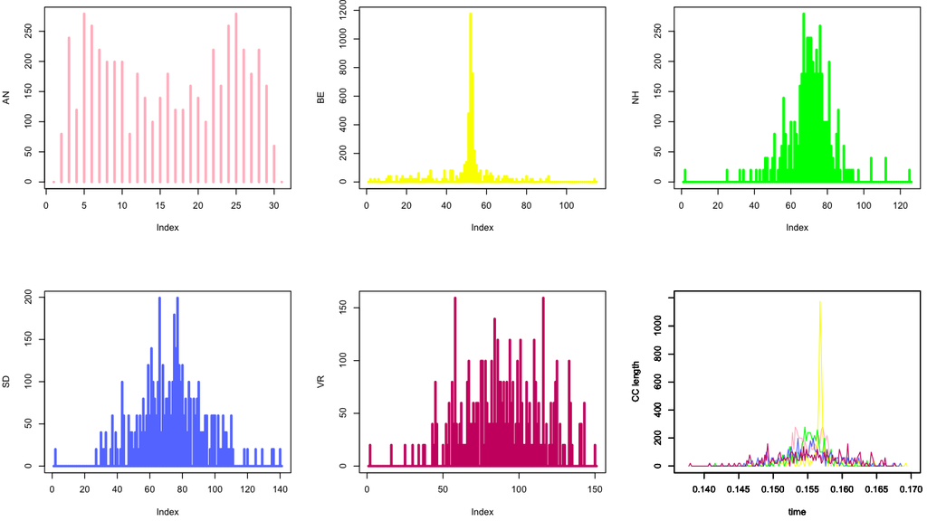

```python
Image(filename = "cc.png", width=1000, height=900)
```

#### Время работы алгоритмов в секундах:

метод Берендсена: 3.29

метод "Velocity rescale": 3.66

метод Нуза-Хувера : 3.52

метод Андерсена: 3.24

метод стохастической молекулярной динамики: 4.09